# Week 15 · Make the evidence agree before you communicate it

MATH 346 course companion · Figures, files and defensible claims

**Note**

Use this chapter with the [companion reading guide](https://lnajman.github.io/math346/companion/how-to-use.html). **Nothing in this chapter is collected or graded.** The approved syllabus, workload guide and Blackboard remain authoritative.

## Your route

**Can another reader reproduce your results and trace each important sentence to the same evidence?**

We bring the familiar model, files and interpretation together. A runnable script, plausible CSV and readable report can disagree. This chapter shows how to generate and inspect an evidence bundle, read a prediction figure, find inconsistencies and repair overstrong generated prose.

Before you start · Words used here · Setup · Meeting 1 · Meeting 2 · AI audit · Practice and project transfer.

**TipA first 30-minute session**

Choose a stopping point within about 30 minutes and resume later. This is an untested stopping budget, not a completion promise.

1. Check setup and the role of each artifact.
2. Inspect the declared training/validation split and prediction figure.
3. Try a caption, then read the saved-file checks.
4. Identify one deliberate audit mismatch and choose your next Core step.

Read displayed results when jumping ahead; run code in order when returning to your script. The full route is Core **1, 4, 5, 6, 8, 12**, selective Guided **2, 3, 7, 9, 10, 11**, with **no Extension exercises**. Reading and selected lab/exercise work share the **90–120-minute ordinary-week practice budget**. Project work remains separately scheduled. Both class meetings retain 75 minutes and a final five-minute individual exit; follow any announced reduced selection.

### Before you start

Use [Week 13](https://lnajman.github.io/math346/companion/week-13.html) for formulas, residuals and error metrics, and [Week 14](https://lnajman.github.io/math346/companion/week-14.html) for retaining model evidence and sensitivity. You should recognize source IDs, CSVs and checked function calls. This chapter introduces no new model or dataset.

Slides provide lecture flow, this chapter explains and checks it, and selected labs/exercises provide practice. You do not need to author Quarto: Project 2 still uses the approved report template exported to PDF, R source and required CSV files. The `airquality` outputs below are practice artifacts, not project submission evidence.

**NoteWords used in this chapter**

| Word or pattern | Meaning here |
| --- | --- |
| **Artifact / bundle** | A file or display carrying evidence / the related outputs from one analysis. |
| **Schema** | Required column names, order and types. |
| **Manifest** | An inventory naming artifacts, their roles and a declared generating script. |
| **Identity line** | The line where predicted equals observed; it is not a fitted regression line. |
| **RMSE / MAE** | Root mean squared error / mean absolute error, both in response units. |
| **Residual / absolute error** | Observed minus predicted / the magnitude of that difference. |
| **Exact / display value** | Stored computed precision / a rounded number used for communication. |
| **Tolerance** | A declared allowable difference, such as 0.01 ppb for a displayed metric. |
| **Reconciliation** | Check that files, figures and prose describe the same rows, formula and values. |
| **Clean run / hidden state** | Run from a fresh session / an old object or manual action on which code silently depends. |
| **Claim ledger** | A table linking each claim to evidence, scope and limitation. |
| **Sensitivity / validation** | A declared change to test fragility / evaluation on rows not used to fit the model. |

### Read / Explain / Check / Interpret

Read the producing code and artifact; explain what should agree; check the saved evidence; interpret with scope and limitations. Think first; write a private comment only where requested—see the [prediction guide](https://lnajman.github.io/math346/companion/how-to-use.html#read-explain-check-interpret).

## Setup

Use R 4.1 or later, `dplyr` and `ggplot2`. Save the bundle starter and audit starter in a `week15/` folder. The AI critique target is for selected Guided 11 work; no AI account or external call is needed. All examples use built-in data, not private group files.

Run this from your `week15/` folder:

```r
required_files <- c("week15-evidence-bundle.R", "week15-cross-artifact-audit.R")
```

```r
missing_files <- required_files[!file.exists(required_files)]
missing_packages <- c("dplyr", "ggplot2")[!vapply(
  c("dplyr", "ggplot2"), requireNamespace, logical(1), quietly = TRUE
)]
if (length(missing_files) + length(missing_packages) == 0) {
  cat("Setup OK\n")
} else {
  cat("Missing files:", paste(missing_files, collapse = ", "), "\n")
  cat("Missing packages:", paste(missing_packages, collapse = ", "), "\n")
}
```

**Example output when the files and packages are available:**

```
Setup OK
```

Run the check on your own computer; this printed example cannot confirm its setup. Use `getwd()` for path problems and the [software checks](https://lnajman.github.io/math346/resources/software-requirements.html) for package help. Restart R, then run the chapter’s code in order, including the code inside the reference reveals.

Each complete reference rebuilds its own objects. Keep the saved scripts separate; running the next reference deliberately replaces names such as `fit` and `model_data`. Evidence chunks use the reference object names; run that reference first, or adapt the names to your own completed starter.

## Meeting 1 · Give each artifact a job

**Slide cues:** “The Submission Is A System”, “Five Artifacts”, “Correct Separately Is Not Enough” and “Freeze Before Polishing”.

The five artifacts are R source, results CSV, prediction CSV, figure and PDF report.

**Predict in a private comment first:** a results CSV reports 29 validation predictions. Does that prove there are 29 correctly aligned prediction rows? Name the artifact and check needed before trusting the statement.

**Compare the artifact roles**

The summary count is not row-level evidence. Read the prediction CSV and compare its count, unique IDs, ID order and values with the validation rows. **If your answer differed,** you may have treated a reported total as a check of the actual saved predictions.

| Artifact | Primary job | What it cannot establish alone |
| --- | --- | --- |
| R source | Recreate the calculation | That its interpretation is defensible |
| Results CSV | Preserve computed metrics and model description | One correct prediction per source row |
| Prediction CSV | Preserve row-level predictions and IDs | An adequate explanation of the whole result |
| Figure | Make pattern and error visible | Causation or broad generalization |
| PDF report | Explain question, reasoning and limitations | Computational reproducibility |

### Generate one declared classroom bundle

**Slide cues:** “Classroom Example”, “Checked Modeling Rows”, “Frozen Analysis”, “First Reconciliation”, “Generate, Do Not Re-Type”, “Artifact Manifest” and “Read It Back”.

The observation is a recorded New York day in May–September 1973; ozone is in ppb, temperature in degrees F and wind in mph. This example fits `ozone_ppb ~ temperature_f + wind_mph` on **May–August only**: 87 complete rows. September supplies **29 validation rows**. Do not reuse the Week 13 model fitted on all 116 rows: it would already include these validation observations.

For Core 1/5/12, identify the producing code, expected files and read-back checks in your starter before opening the reference. Its output is three evidence artifacts plus a manifest—not a PDF report.

**Reference version · Generate and read back the evidence**

```r
# MATH 346 - possible worked solution
# Compare only after attempting the starter; other correct implementations are possible.

library(dplyr)
library(ggplot2)

rmse <- function(observed, predicted) {
  sqrt(mean((observed - predicted)^2))
}

mae <- function(observed, predicted) {
  mean(abs(observed - predicted))
}

model_data <- airquality |>
  transmute(
    observation_id = row_number(),
    month = factor(month.abb[Month], levels = month.abb[5:9]),
    ozone_ppb = Ozone,
    temperature_f = Temp,
    wind_mph = Wind
  ) |>
  filter(complete.cases(ozone_ppb, temperature_f, wind_mph))

training <- model_data |> filter(month != "Sep")
validation <- model_data |> filter(month == "Sep")
frozen_formula <- ozone_ppb ~ temperature_f + wind_mph

fit <- lm(frozen_formula, data = training)
training_predictions <- predict(fit)
validation_predictions <- predict(fit, newdata = validation)
baseline_value <- mean(training$ozone_ppb)

sensitivity_index <- which.max(abs(rstandard(fit)))
sensitivity_removed_id <- training$observation_id[[sensitivity_index]]
sensitivity_fit <- lm(frozen_formula, data = training[-sensitivity_index, ])
sensitivity_predictions <- predict(sensitivity_fit, newdata = validation)

results <- tibble(
  n_training_rows = nrow(training),
  n_validation_rows = nrow(validation),
  formula = paste(deparse(frozen_formula), collapse = " "),
  baseline_validation_rmse_ppb = rmse(validation$ozone_ppb, baseline_value),
  training_rmse_ppb = rmse(training$ozone_ppb, training_predictions),
  validation_rmse_ppb = rmse(validation$ozone_ppb, validation_predictions),
  validation_mae_ppb = mae(validation$ozone_ppb, validation_predictions),
  sensitivity_removed_observation_id = sensitivity_removed_id,
  sensitivity_validation_rmse_ppb = rmse(
    validation$ozone_ppb,
    sensitivity_predictions
  )
)

prediction_table <- validation |>
  transmute(
    observation_id,
    observed_ozone_ppb = ozone_ppb,
    prediction_ppb = as.numeric(validation_predictions),
    residual_ppb = observed_ozone_ppb - prediction_ppb
  )

largest_error <- prediction_table |>
  slice_max(abs(residual_ppb), n = 1, with_ties = FALSE)

validation_plot <- ggplot(
  prediction_table,
  aes(x = observed_ozone_ppb, y = prediction_ppb)
) +
  geom_abline(slope = 1, intercept = 0, linetype = "dashed") +
  geom_point(size = 2) +
  geom_text(
    data = largest_error,
    aes(label = paste("ID", observation_id)),
    nudge_y = 4
  ) +
  coord_equal() +
  labs(
    title = "Frozen-model predictions for September",
    subtitle = "The dashed line marks perfect observed-predicted agreement",
    x = "Observed ozone (ppb)",
    y = "Predicted ozone (ppb)",
    caption = paste(
      "Each point is one of", nrow(validation),
      "complete September observations; ID marks the largest absolute error."
    )
  )

bundle_directory <- file.path(tempdir(), "math346-week15-evidence")
dir.create(bundle_directory, showWarnings = FALSE)

results_path <- file.path(bundle_directory, "week15-results.csv")
predictions_path <- file.path(bundle_directory, "week15-predictions.csv")
figure_path <- file.path(bundle_directory, "week15-validation-figure.png")
manifest_path <- file.path(bundle_directory, "week15-manifest.csv")

write.csv(results, results_path, row.names = FALSE)
write.csv(prediction_table, predictions_path, row.names = FALSE)
ggsave(figure_path, validation_plot, width = 7, height = 6, dpi = 120)

manifest <- tibble(
  artifact = basename(c(results_path, predictions_path, figure_path)),
  role = c(
    "exact summary values",
    "one prediction per validation observation",
    "visual prediction evidence"
  ),
  generated_by = "week15-evidence-bundle.R"
)
write.csv(manifest, manifest_path, row.names = FALSE)

results_check <- read.csv(results_path, check.names = FALSE)
predictions_check <- read.csv(predictions_path, check.names = FALSE)
manifest_check <- read.csv(manifest_path, check.names = FALSE)
plot_build <- ggplot_build(validation_plot)

stopifnot(
  nrow(training) == 87,
  nrow(validation) == 29,
  sensitivity_removed_id == 117,
  abs(results$validation_rmse_ppb - 17.93979) < 1e-5,
  abs(results$validation_mae_ppb - 14.89114) < 1e-5,
  results$validation_rmse_ppb < results$baseline_validation_rmse_ppb,
  identical(prediction_table$observation_id, validation$observation_id),
  nrow(results_check) == 1,
  nrow(predictions_check) == nrow(validation),
  nrow(manifest_check) == 3,
  nrow(plot_build$data[[2]]) == nrow(validation),
  file.info(figure_path)$size > 1000
)

print(results)
```

```
# A tibble: 1 × 9
  n_training_rows n_validation_rows formula               baseline_validation_…¹
            <int>             <int> <chr>                                  <dbl>
1              87                29 ozone_ppb ~ temperat…                   27.7
# ℹ abbreviated name: ¹baseline_validation_rmse_ppb
# ℹ 5 more variables: training_rmse_ppb <dbl>, validation_rmse_ppb <dbl>,
#   validation_mae_ppb <dbl>, sensitivity_removed_observation_id <int>,
#   sensitivity_validation_rmse_ppb <dbl>
```

```r
print(manifest)
```

```
# A tibble: 3 × 3
  artifact                     role                                 generated_by
  <chr>                        <chr>                                <chr>
1 week15-results.csv           exact summary values                 week15-evid…
2 week15-predictions.csv       one prediction per validation obser… week15-evid…
3 week15-validation-figure.png visual prediction evidence           week15-evid…
```

```r
cat("Week 15 evidence bundle passed row, value, alignment, and file checks.\n")
```

```
Week 15 evidence bundle passed row, value, alignment, and file checks.
```

The result contains training RMSE about **22.93 ppb**, validation RMSE **17.94 ppb**, validation MAE **14.89 ppb**, and baseline validation RMSE **27.67 ppb**. The baseline repeats the **training** mean on validation rows; it does not calculate a new mean from September outcomes. R repeats the single baseline value across 29 rows; model predictions use the aligned 29-value vector, since these small helpers do not check lengths or missingness.

The script writes four temporary files. These **example-output downloads** contain one checked run, for reading if R is unavailable or your temporary files are gone. They are not Project 2 evidence or confirmation of your own run:

| File | Contents |
| --- | --- |
| week15-results.csv | One row, nine summary/model fields |
| week15-predictions.csv | 29 rows: ID, observed ozone, prediction and residual |
| week15-validation-figure.png | Observed-versus-predicted figure |
| week15-manifest.csv | Three inventory rows, one for each evidence artifact above |

The manifest lists three artifacts, not itself; its inventory is not proof of correct generation. Type `bundle_directory` on your computer to find the current temporary folder. Copy outputs you want before closing R; a new session needs a new run, not an old temporary path.

### Inspect the saved evidence, not only memory

**Slide cues:** “Exact And Display Values”, “Source Identifier Check” and “A Figure Contract”.

These checks use the reference object names. Run the bundle reference first, or adapt the names to your completed starter. `read.csv` in that reference created the `*_check` objects from the newly written files.

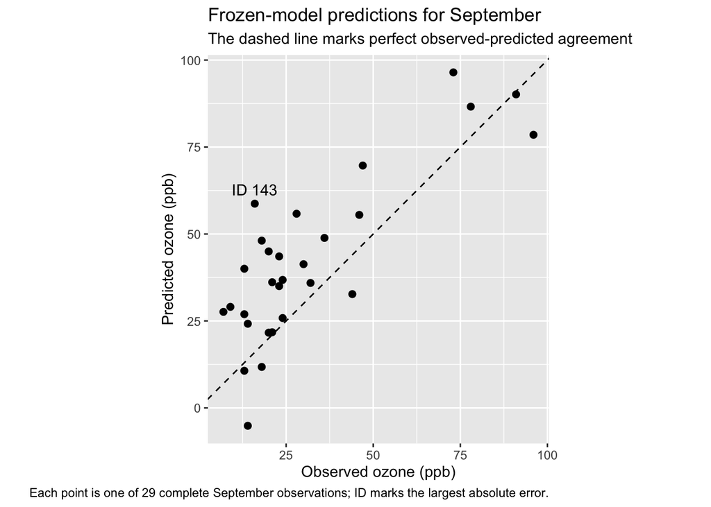

```r
print(validation_plot)
```

```r
numeric_results <- results_check[setdiff(names(results_check), "formula")]
stopifnot(
  identical(names(results_check), c("n_training_rows", "n_validation_rows",
    "formula", "baseline_validation_rmse_ppb", "training_rmse_ppb",
    "validation_rmse_ppb", "validation_mae_ppb",
    "sensitivity_removed_observation_id", "sensitivity_validation_rmse_ppb")),
  identical(names(predictions_check), c("observation_id", "observed_ozone_ppb",
                                      "prediction_ppb", "residual_ppb")),
  identical(names(manifest_check), c("artifact", "role", "generated_by")),
  nrow(results_check) == 1, nrow(predictions_check) == 29,
  !anyNA(results_check), !anyNA(predictions_check),
  results_check$formula == paste(deparse(frozen_formula), collapse = " "),
  all(vapply(numeric_results, function(x) is.numeric(x) && all(is.finite(x)),
             logical(1))),
  !anyDuplicated(predictions_check$observation_id),
  identical(predictions_check$observation_id, validation$observation_id),
  isTRUE(all.equal(predictions_check$observed_ozone_ppb, validation$ozone_ppb)),
  isTRUE(all.equal(predictions_check$prediction_ppb,
                   as.numeric(validation_predictions), tolerance = 1e-10)),
  abs(results_check$validation_rmse_ppb - sqrt(mean(
    (predictions_check$observed_ozone_ppb - predictions_check$prediction_ppb)^2
  ))) < 1e-10,
  all(vapply(predictions_check, function(x) all(is.finite(x)), logical(1))),
  setequal(manifest_check$artifact,
           basename(c(results_path, predictions_path, figure_path))),
  all(file.exists(file.path(bundle_directory, manifest_check$artifact))),
  max(abs(predictions_check$observed_ozone_ppb -
          predictions_check$prediction_ppb - predictions_check$residual_ppb)) < 1e-10
)
```

A silent `stopifnot` means its conditions passed; an error names the failed condition. Reading the saved CSV can reveal a stale file, omitted column or lost row that a correct in-memory table would not show. Count checks need identity and order checks too. In a new folder, a complete run should need only the saved source, declared inputs and packages—not objects left in memory. This is Core 12’s clean-run rehearsal.

### Make the caption carry evidence

**Slide cues:** “One Figure, One Main Job”, “Observed Versus Predicted”, “The Identity Line”, “Caption Test” and “Stronger Caption”.

The horizontal axis is **observed** ozone and the vertical axis is **predicted** ozone, in ppb. One point is one complete September observation; the dashed line has slope 1 and intercept 0, so it marks equality. The label is an original source ID, not a point’s position in the 29-row table. One prediction is below zero: that is a limitation of the unconstrained linear model, not a negative source measurement. Keep that prediction visible rather than clipping it out of the display.

**Think first:** count points above versus below the dashed line. What direction of error does that suggest, and what does it show that RMSE alone does not? Check the row counts in the reveal if points overlap.

**Predict in a private comment first:** for Core 4, draft your caption in your script before expanding. Use its four sentences to name the subset/variables, explain the line, describe a checked pattern and state a limitation. Think through whether a point above the line is overpredicted or underpredicted.

**Compare the figure reading and a possible caption**

Use the saved prediction rows for exact counts; these names come from the bundle reference and read-back check above.

```r
direction_check <- data.frame(
  above_line = sum(predictions_check$prediction_ppb > predictions_check$observed_ozone_ppb),
  below_line = sum(predictions_check$prediction_ppb < predictions_check$observed_ozone_ppb),
  mean_residual_ppb = mean(predictions_check$residual_ppb)
)
direction_check
```

```
  above_line below_line mean_residual_ppb
1         23          6         -10.93942
```

The model overpredicts **23 of these 29 September days**; six points lie below the line. The mean observed-minus-predicted residual is about **-10.94 ppb**: predictions are about 10.94 ppb higher on average. RMSE measures error magnitude but loses its sign, so beating the baseline can coexist with this directional pattern. This describes the checked September subset, not all future periods.

Above the line, prediction exceeds observation: the model overpredicts. The residual `observed - predicted` is negative there. Source ID **143** has observed ozone 16 ppb and predicted ozone about 58.72 ppb, an absolute error of about **42.72 ppb**. It is the largest validation error. Source ID **117**, in contrast, is the training observation omitted for the sensitivity refit.

A possible four-sentence caption is:

> Observed and frozen-model predicted ozone (ppb) are shown for 29 complete September days, with one point per day. The dashed line marks equality, and ID 143 identifies the largest absolute prediction error, about 42.72 ppb. The model overpredicts 23 of 29 days with mean residual about -10.94 ppb, even though its RMSE of 17.94 ppb is below the baseline’s 27.67 ppb. This check covers one period in this dataset and does not establish causation or performance in all seasons.

**If your answer differed,** you may have swapped the axes, mistaken the identity line for a fitted trend, overlooked the directional pattern, or read the lower-average-error claim as if every prediction were close. This is one possible caption, not a unique required answer.

**Individual in-class exit, final five minutes:** which artifact is authoritative for exact metrics, row-level predictions, interpretation and limitations, and reproducible computation? Follow the announced classroom route.

**Self-check (no submission):** a saved prediction file has all 29 correct IDs, but its rows are permuted relative to validation. Which check detects this, and what must stay together when repairing the order?

**Compare the Meeting 1 self-check**

`identical` on the two ID vectors fails the declared order contract. Reorder whole ID-linked rows, or align by ID and verify the contract afterward; do not sort the prediction values separately. A count or ID-set check alone misses this order difference.

## Meeting 2 · Reconcile values and claims

**Slide cues:** “Clean-Run Rehearsal”, “Hidden-State Failure”, “Cross-Artifact Audit”, “Tolerance Zero”, “Small Display Tolerance” and “Three Deliberate Mismatches”.

### Passing an audit script is not agreement

For Core 6, compare the proposed reported values with the earlier saved results: training rows 116, validation rows 29, prediction rows 28, RMSE 15.80 and MAE 14.89. Which look like stale or incorrect values, and which are acceptable rounding? Think first, then compare the complete audit. These deliberately wrong reported values do not mean the correctly generated prediction CSV above actually lost a row.

The reference below is self-contained for a fresh session. It **constructs** reported/computed vectors to illustrate mismatches; it does not parse an actual PDF or read the preceding bundle’s CSV files. The saved-file checks above are the separate check of those files.

**Reference version · Find the deliberate disagreements**

```r
# MATH 346 - possible worked solution
# Compare only after attempting the starter; other correct implementations are possible.

library(dplyr)

rmse <- function(observed, predicted) {
  sqrt(mean((observed - predicted)^2))
}

mae <- function(observed, predicted) {
  mean(abs(observed - predicted))
}

model_data <- airquality |>
  transmute(
    observation_id = row_number(),
    month = factor(month.abb[Month], levels = month.abb[5:9]),
    ozone_ppb = Ozone,
    temperature_f = Temp,
    wind_mph = Wind
  ) |>
  filter(complete.cases(ozone_ppb, temperature_f, wind_mph))

training <- model_data |> filter(month != "Sep")
validation <- model_data |> filter(month == "Sep")
fit <- lm(
  ozone_ppb ~ temperature_f + wind_mph,
  data = training
)

validation_predictions <- predict(fit, newdata = validation)
baseline_value <- mean(training$ozone_ppb)
sensitivity_index <- which.max(abs(rstandard(fit)))

computed_values <- c(
  training_rows = nrow(training),
  validation_rows = nrow(validation),
  prediction_rows = length(validation_predictions),
  validation_rmse = rmse(validation$ozone_ppb, validation_predictions),
  validation_mae = mae(validation$ozone_ppb, validation_predictions),
  sensitivity_removed_id = training$observation_id[[sensitivity_index]],
  model_beats_baseline = as.numeric(
    rmse(validation$ozone_ppb, validation_predictions) <
      rmse(validation$ozone_ppb, baseline_value)
  )
)

# These values imitate a report assembled from several stale or mistyped sources.
reported_values <- c(
  training_rows = 116,
  validation_rows = 29,
  prediction_rows = 28,
  validation_rmse = 15.80,
  validation_mae = 14.89,
  sensitivity_removed_id = 117,
  model_beats_baseline = 1
)

tolerances <- c(
  training_rows = 0,
  validation_rows = 0,
  prediction_rows = 0,
  validation_rmse = 0.01,
  validation_mae = 0.01,
  sensitivity_removed_id = 0,
  model_beats_baseline = 0
)

source_artifact <- c(
  "PDF data section",
  "results CSV",
  "prediction CSV",
  "PDF conclusion",
  "figure caption",
  "sensitivity section",
  "PDF conclusion"
)

artifact_audit <- tibble(
  item = names(computed_values),
  source_artifact,
  reported_value = as.numeric(reported_values),
  computed_value = as.numeric(computed_values),
  tolerance = as.numeric(tolerances),
  difference = abs(reported_value - computed_value),
  status = if_else(difference <= tolerance, "agrees", "mismatch")
)

required_exact_items <- c(
  "training_rows", "validation_rows", "prediction_rows",
  "sensitivity_removed_id"
)

release_ready <- !any(
  artifact_audit$status == "mismatch" &
    artifact_audit$item %in% required_exact_items
)

stopifnot(
  identical(
    artifact_audit$status,
    c("mismatch", "agrees", "mismatch", "mismatch", "agrees", "agrees", "agrees")
  ),
  sum(artifact_audit$status == "mismatch") == 3,
  !release_ready,
  artifact_audit$computed_value[artifact_audit$item == "prediction_rows"] == 29,
  artifact_audit$computed_value[artifact_audit$item == "sensitivity_removed_id"] == 117
)

print(artifact_audit)
```

```
# A tibble: 7 × 7
  item        source_artifact reported_value computed_value tolerance difference
  <chr>       <chr>                    <dbl>          <dbl>     <dbl>      <dbl>
1 training_r… PDF data secti…          116             87        0      29
2 validation… results CSV               29             29        0       0
3 prediction… prediction CSV            28             29        0       1
4 validation… PDF conclusion            15.8           17.9      0.01    2.14
5 validation… figure caption            14.9           14.9      0.01    0.00114
6 sensitivit… sensitivity se…          117            117        0       0
7 model_beat… PDF conclusion             1              1        0       0
# ℹ 1 more variable: status <chr>
```

```r
cat("Release ready:", release_ready, "\n")
```

```
Release ready: FALSE
```

```r
cat("Week 15 cross-artifact audit found three deliberate inconsistencies.\n")
```

```
Week 15 cross-artifact audit found three deliberate inconsistencies.
```

Three mismatches are deliberate: **116 versus 87 training rows**, **28 versus 29 prediction rows**, and **15.80 versus about 17.94 validation RMSE**. MAE 14.89 differs from 14.891139 by about 0.001139 and passes its 0.01 ppb display tolerance. Counts and IDs use zero tolerance. Do not choose a tolerance after seeing a discrepancy merely to make it pass.

The `stopifnot` calls pass because the program correctly detected the expected three mismatches and `release_ready` is `FALSE`. They do not certify that the reported artifacts agree. That boolean checks selected exact-count/ID items; it is not a complete release decision if some other material claim disagrees. Read the whole audit, not only its final boolean.

**If your answer differed,** you may have treated every display difference as an error or treated successful execution as permission to release.

If the PDF is stale but newly generated evidence is correct, repair the report and recheck. If analysis rows, prediction output or formula are wrong, repair the producing code and regenerate dependent outputs. An unexplained discrepancy needs review. Never manually edit a CSV value to force agreement.

### Keep sensitivity in its declared role

**Slide cues:** “Sensitivity Has A Declared Role”, “Average Error Is Not Every Error” and “Baseline Comparison”.

**Predict · Think first:** sensitivity validation RMSE is about **16.68 ppb**, lower than the primary model’s 17.94 ppb. Should the sensitivity model silently replace the frozen primary model?

**Compare the sensitivity interpretation**

No. The declared question is whether the conclusion changes under one training-row omission. Report the lower metric and the changed fit as sensitivity evidence; it is not permission to select a new primary model using validation outcomes. The primary comparison remains 17.94 versus the baseline’s 27.67 ppb. **If your answer differed,** you may have turned a planned robustness check into unreported model selection.

RMSE and MAE summarize errors across the 29 rows. Neither says every prediction is accurate, and no acceptable-error threshold for every day has been declared. The 42.72 ppb largest error is evidence to retain alongside the averages.

### Build the conclusion from a claim ledger

**Slide cues:** “Claim Ledger”, “Four Different Claim Types” and “Repair Rules”.

For Core 8, make each statement traceable before polishing prose:

| Claim type | Classroom evidence and scope | Limitation |
| --- | --- | --- |
| Description | 29 complete September validation days | Not every original day or season |
| Association | Temperature/wind coefficients from the declared training fit | Observational adjusted relationship, not intervention evidence |
| Prediction | Frozen model’s September RMSE below the training-mean baseline | One dataset/period; one large error remains |
| Sensitivity | Declared training-row omission changes validation RMSE | One planned check, not replacement-model selection |

A numerical check cannot establish causation from this study design. A clear figure cannot erase missing outcomes, limited predictors or narrow validation scope. Keep the evidence and limitation attached to each claim.

## Guided audit · Check every clause in generated prose

**Slide cues:** “AI-Polished Conclusion”, “Split At Logical Connectors”, “Claim-Level AI Audit” and “Repair Rules”.

Use selectively for Guided 11; this is not a second required lab. Read the supplied paragraph before the evidence reveal:

> “The model proves that hot, calm weather causes high ozone. Its validation RMSE is lower than the mean baseline, so every September day is predicted accurately and the model will generalize to all seasons. The sensitivity refit has lower validation RMSE and should replace the frozen model. The clear figure means that limitations are negligible.”

**Predict in a private comment first:** separate the supported baseline comparison from the claim joined to it by “so.” Name the evidence for each and repair the unsupported conclusion using checked values and scope.

**Compare the evidence and run the supplied claim audit**

```r
library(dplyr)

rmse <- function(observed, predicted) {
  sqrt(mean((observed - predicted)^2))
}

model_data <- airquality |>
  transmute(
    observation_id = row_number(),
    month = factor(month.abb[Month], levels = month.abb[5:9]),
    ozone_ppb = Ozone,
    temperature_f = Temp,
    wind_mph = Wind
  ) |>
  filter(complete.cases(ozone_ppb, temperature_f, wind_mph))

training <- model_data |> filter(month != "Sep")
validation <- model_data |> filter(month == "Sep")
fit <- lm(
  ozone_ppb ~ temperature_f + wind_mph,
  data = training
)

validation_predictions <- predict(fit, newdata = validation)
baseline_predictions <- rep(mean(training$ozone_ppb), nrow(validation))
sensitivity_index <- which.max(abs(rstandard(fit)))
sensitivity_fit <- lm(
  ozone_ppb ~ temperature_f + wind_mph,
  data = training[-sensitivity_index, ]
)
sensitivity_predictions <- predict(sensitivity_fit, newdata = validation)

validation_rmse <- rmse(validation$ozone_ppb, validation_predictions)
baseline_validation_rmse <- rmse(validation$ozone_ppb, baseline_predictions)
sensitivity_validation_rmse <- rmse(
  validation$ozone_ppb,
  sensitivity_predictions
)
largest_absolute_error <- max(abs(validation$ozone_ppb - validation_predictions))

generated_conclusion <- paste(
  "The model proves that hot, calm weather causes high ozone.",
  "Its validation RMSE is lower than the mean baseline, so every September",
  "day is predicted accurately and the model will generalize to all seasons.",
  "The sensitivity refit has lower validation RMSE and should replace the",
  "frozen model. The clear figure means that limitations are negligible."
)

claim_audit <- tibble(
  generated_claim = c(
    "weather causes high ozone",
    "validation RMSE is lower than the mean baseline",
    "every September day is predicted accurately",
    "the model will generalize to all seasons",
    "the sensitivity refit should replace the frozen model",
    "limitations are negligible"
  ),
  verdict = c(
    "unsupported",
    "supported",
    "contradicted",
    "unsupported",
    "unsupported",
    "unsupported"
  ),
  evidence = c(
    "observational regression supports association, not causation",
    sprintf(
      "model RMSE %.1f ppb is below baseline RMSE %.1f ppb",
      validation_rmse, baseline_validation_rmse
    ),
    sprintf("the largest absolute validation error is %.1f ppb", largest_absolute_error),
    "validation covers September observations from the same dataset only",
    sprintf(
      "the frozen plan remains primary; sensitivity RMSE is %.1f ppb",
      sensitivity_validation_rmse
    ),
    "missing outcomes, limited predictors, observational data, and one validation period remain"
  ),
  repair = c(
    "describe adjusted association",
    "retain with the two rounded values",
    "report average performance and the largest error",
    "limit the claim to the validation setting",
    "report sensitivity as robustness evidence",
    "state the material limitations"
  )
)

stopifnot(
  abs(validation_rmse - 17.93979) < 1e-5,
  validation_rmse < baseline_validation_rmse,
  sensitivity_validation_rmse < validation_rmse,
  largest_absolute_error > 40,
  sum(claim_audit$verdict == "supported") == 1,
  sum(claim_audit$verdict != "supported") == 5
)

cat(generated_conclusion, "\n\n")
```

[output not shown]

```r
print(claim_audit)
```

```
# A tibble: 6 × 4
  generated_claim                                       verdict  evidence repair
  <chr>                                                 <chr>    <chr>    <chr>
1 weather causes high ozone                             unsuppo… observa… descr…
2 validation RMSE is lower than the mean baseline       support… model R… retai…
3 every September day is predicted accurately           contrad… the lar… repor…
4 the model will generalize to all seasons              unsuppo… validat… limit…
5 the sensitivity refit should replace the frozen model unsuppo… the fro… repor…
6 limitations are negligible                            unsuppo… missing… state…
```

```r
cat("Week 15 AI conclusion audit retained one claim and repaired five.\n")
```

```
Week 15 AI conclusion audit retained one claim and repaired five.
```

Only one of the six listed claims is supported: lower validation RMSE than the baseline, about **17.94 versus 27.67 ppb**. The comparison does not imply accurate prediction of every day, all-season performance, causation, permission to replace the frozen model or negligible limitations. The observation with error about 42.72 ppb is an important counterexample to unqualified individual accuracy.

A defensible conclusion states the declared split and formula, retains the baseline comparison, reports the large error and sensitivity result, and limits the claim to these complete September observations. It describes any coefficient as an adjusted association, not an established cause.

**If your answer differed,** you may have accepted the whole sentence because its first clause was numerically correct. Check each claim and logical connector, not just each number. Retain material AI assistance and human checks under the [course AI policy](https://lnajman.github.io/math346/syllabus/ai-policy.html). Do not upload private group/student information or assessment keys to an external tool.

**Individual in-class exit, final five minutes:** “Why can individually plausible artifacts still form an indefensible submission?” Follow the announced classroom route.

**Self-check (no submission):** a release check returns `TRUE` for all row counts, but the PDF’s validation RMSE differs from the exact CSV by 2 ppb, beyond its 0.01 ppb tolerance. Does the count check settle the release decision? What next?

**Compare the Meeting 2 self-check**

No. A passed count check says nothing about that metric disagreement. Trace the reported value to the generating analysis and saved file. Repair a stale report or the producing code as appropriate, rerun the affected checks and keep the release blocked until the material discrepancy is explained and corrected.

## Practice and final project transfer

| Work | Practice supported here |
| --- | --- |
| **Core 1, 4** | Assign artifact roles and write an evidence-bearing caption |
| **Core 5, 6** | Read generated files back and reconcile reported values |
| **Core 8, 12** | Build a claim ledger and rehearse a clean complete run |
| **Guided 2, 3, 7, 9, 10, 11** | Freeze the communication contract, audit the figure/tolerances/errors, interpret sensitivity and review generated prose; use selectively |
| **Extension** | None in this set |

Keep this checked practice for your own use and any checkpoint requested on Blackboard. The classroom outputs must not be submitted as Project 2 evidence.

**Possible solutions · Compare after your attempt**

- Evidence-bundle possible solution
- Cross-artifact possible solution

These are unchanged public comparison files; other correct implementations are possible. Keep checks whose purpose you can explain.

For Project 2, map the **already required** PDF, R source, results CSV and validation-predictions CSV to their producing code and checks. Use your assigned group prefix and package, not the classroom `week15-` names. Follow the [Project 2 file contract](https://lnajman.github.io/math346/projects/project-2-modeling.html#required-submission) and [milestone map](https://lnajman.github.io/math346/projects/project-milestones.html) for submission and dates; this chapter sets neither. The classroom manifest is not an additional required project file, and reading this page adds no Quarto authoring requirement.

Before the group submits, every member should be able to find the producing code, explain formula/metric, interpret a figure, state a limitation/sensitivity result and describe their contribution and material AI assistance. Complete the approved report’s AI-use appendix and contribution statement; do not replace those with a separate companion form.

If an object is missing, restart and rerun its defining reference, or adapt names to your completed starter. If a file is missing, check the current run’s temporary folder. If a clean rerun changes an important result without explanation, retain the evidence and ask for review rather than polishing around the discrepancy.

**Where this fits:** [Week 15 notes](https://lnajman.github.io/math346/weeks/week-15.html) · [Slides](https://lnajman.github.io/math346/slides/week-15.html) · [Main lab](https://lnajman.github.io/math346/labs/lab-15-evidence-reconciliation.html) · [AI-review lab](https://lnajman.github.io/math346/labs/lab-15-ai-conclusion-review.html) · [Exercises](https://lnajman.github.io/math346/weeks/week-15-exercises.html).

[Published companion chapters](https://lnajman.github.io/math346/companion/index.html).